# Homework 2

Author

Published

September 15, 2024

# Load Packages

The following packages were used in this homework.

```r
library(Hmisc)
library(NHANES)
library(janitor)
library(kableExtra)
library(tidyverse)
```

# Introduction

In this homework, I will…

- Describe numerical distributions
- Select the appropriate summary statistics based on distribution shape
- Match numerical distributions to their summary statistics
- Calculate proportions from a contingency table

# The Data

I will use the following data source for problems 1, 2, and 4.

## Source

- [National Health and Nutrition Examination Survey](https://www.cdc.gov/nchs/nhanes/index.htm) (NHANES), a program of studies designed to assess the health and nutritional status of adults and children in the United States
- Survey combines data from interviews (demographic, socioeconomic, dietary, and health-related questions), physical examinations, and laboratory tests.
- This data set contains 5000 observations from the 2009-2010 survey and 5000 observations from the 2011-2012 survey.

## Codebook

Below are descriptions of the variables used in this homework.

[output not shown]

## Loading the Data

I loaded the data into RStudio and selected the variables I would be analyzing.

```r
## Load the NHANES data set from the package
nhanes_df <- NHANES |>
  select(Weight, Height, Pulse,
         BPDiaAve, AgeMonths, DiabetesAge,
         Gender, SleepTrouble)

head(nhanes_df)
```

```
# A tibble: 6 × 8
  Weight Height Pulse BPDiaAve AgeMonths DiabetesAge Gender SleepTrouble
   <dbl>  <dbl> <int>    <int>     <int>       <int> <fct>  <fct>
1   87.4   165.    70       85       409          NA male   Yes
2   87.4   165.    70       85       409          NA male   Yes
3   87.4   165.    70       85       409          NA male   Yes
4   17     105.    NA       NA        49          NA male   <NA>
5   86.7   168.    86       75       596          NA female Yes
6   29.8   133.    82       47       115          NA male   <NA>
```

# Numerical Summary

Before performing any analysis, I looked summary statistics for my variables.

```r
nhanes_df |>
  Hmisc::describe() |>
  html()
```

nhanes_df  
8 Variables 10000 Observations

Weight

| n | missing | distinct | Info | Mean | Gmd | .05 | .10 | .25 | .50 | .75 | .90 | .95 |
| --- | --- | --- | --- | --- | --- | --- | --- | --- | --- | --- | --- | --- |
| 9922 | 78 | 1290 | 1 | 70.98 | 32.31 | 16.0 | 24.6 | 56.1 | 72.7 | 88.9 | 105.4 | 115.8 |

lowest : 2.8 3.6 4.2 4.5 4.6 , highest: 191.1 198.7 203 223 230.7

Height

| n | missing | distinct | Info | Mean | Gmd | .05 | .10 | .25 | .50 | .75 | .90 | .95 |
| --- | --- | --- | --- | --- | --- | --- | --- | --- | --- | --- | --- | --- |
| 9647 | 353 | 980 | 1 | 161.9 | 20.3 | 112.4 | 135.2 | 156.8 | 166.0 | 174.5 | 180.7 | 184.4 |

lowest : 83.6 83.8 84.5 84.8 84.9 , highest: 199.4 199.5 199.6 199.9 200.4

Pulse

| n | missing | distinct | Info | Mean | Gmd | .05 | .10 | .25 | .50 | .75 | .90 | .95 |
| --- | --- | --- | --- | --- | --- | --- | --- | --- | --- | --- | --- | --- |
| 8563 | 1437 | 47 | 0.997 | 73.56 | 13.59 | 56 | 58 | 64 | 72 | 82 | 90 | 94 |

lowest : 40 42 44 46 48 , highest: 124 126 128 134 136

BPDiaAve

| n | missing | distinct | Info | Mean | Gmd | .05 | .10 | .25 | .50 | .75 | .90 | .95 |
| --- | --- | --- | --- | --- | --- | --- | --- | --- | --- | --- | --- | --- |
| 8551 | 1449 | 102 | 0.999 | 67.48 | 15.13 | 44 | 51 | 61 | 69 | 76 | 83 | 87 |

lowest : 0 11 12 14 15 , highest: 108 109 110 114 116

AgeMonths

| n | missing | distinct | Info | Mean | Gmd | .05 | .10 | .25 | .50 | .75 | .90 | .95 |
| --- | --- | --- | --- | --- | --- | --- | --- | --- | --- | --- | --- | --- |
| 4962 | 5038 | 910 | 1 | 420.1 | 298.5 | 22 | 65 | 199 | 418 | 624 | 783 | 857 |

lowest : 0 1 2 3 4 , highest: 954 955 957 958 959

DiabetesAge

| n | missing | distinct | Info | Mean | Gmd | .05 | .10 | .25 | .50 | .75 | .90 | .95 |
| --- | --- | --- | --- | --- | --- | --- | --- | --- | --- | --- | --- | --- |
| 629 | 9371 | 72 | 0.999 | 48.42 | 17.23 | 17.4 | 29.0 | 40.0 | 50.0 | 58.0 | 67.0 | 73.0 |

lowest : 1 3 6 7 8 , highest: 76 77 78 79 80

Gender

| n | missing | distinct |
| --- | --- | --- |
| 10000 | 0 | 2 |

```
 Value      female   male
 Frequency    5020   4980
 Proportion  0.502  0.498
```

SleepTrouble

| n | missing | distinct |
| --- | --- | --- |
| 7772 | 2228 | 2 |

```
 Value         No   Yes
 Frequency   5799  1973
 Proportion 0.746 0.254
```

# Problem 1 - Describing Numerical Distributions

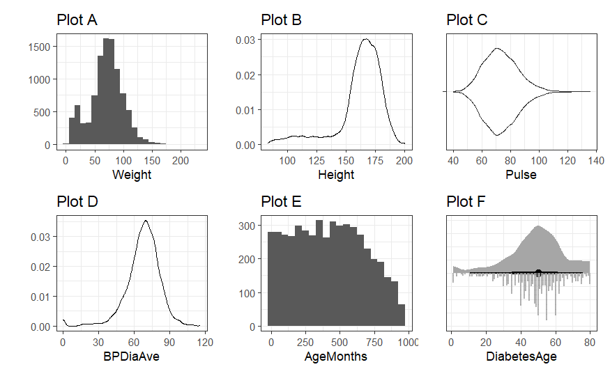

## Bonus Point 2

# Problem 2 - Selecting Summary Statistics

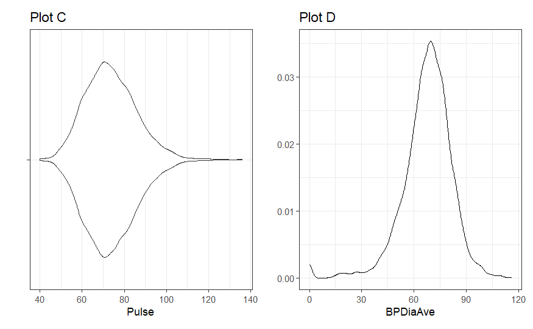

## Plot D

# Problem 3 - Matching Distributions to Statistics

Below are boxplots G-L and in the table below are their 5-number summaries. In the table, I will match each 5-number summary to one boxplots G-L and state whether I expect the mean of the distribution to be greater than, less than, or about equal to the median.

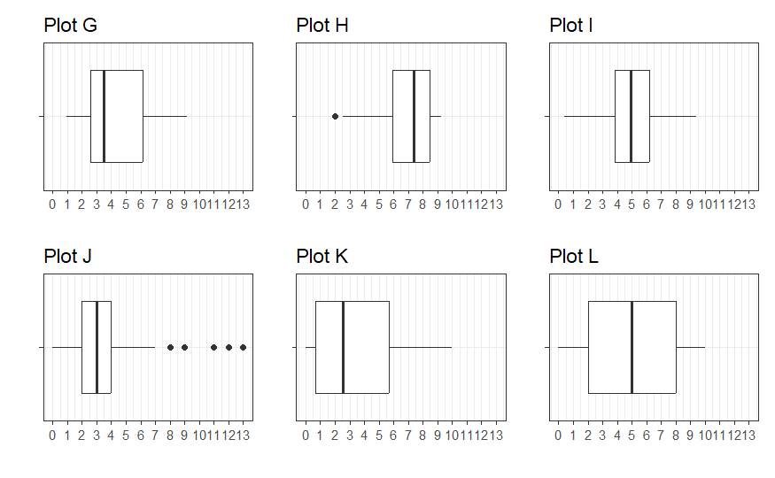

[output not shown]

# Problem 4 - Calculating Proportions for Contingency Tables

I used the `tabyl()` function from the `janitor` package to create a 2 x 2 contingency table of counts from the variables `Gender` and `SleepTrouble` in my data set `nhanes_df`. I excluded subjects with missing data for either variable with the `filter()` function and `is.na()` function. I used the `adorn_totals()` function from the `janitor` package to add totals to both my rows `row` and columns `col`. I then used the functions `kbl()` and `kable_classic()` from the `kableExtra` package to make my table attractive to display.

```r
nhanes_df |>
  filter(!is.na(Gender), !(is.na(SleepTrouble))) |>
  janitor::tabyl(Gender, SleepTrouble) |>
  janitor::adorn_totals(where = c('row', 'col')) |>
  kableExtra::kbl(caption = 'Self-Reported Trouble Sleeping by Gender in the NHANES study for years 2009-2012 (n = 7,772)') |>
  kableExtra::kable_classic(full_width = F)
```

Self-Reported Trouble Sleeping by Gender in the NHANES study for years 2009-2012 (n = 7,772)

| Gender | No | Yes | Total |
| --- | --- | --- | --- |
| female | 2789 | 1164 | 3953 |
| male | 3010 | 809 | 3819 |
| Total | 5799 | 1973 | 7772 |

In the tables below, I will calculate proportions for my contingency table by row and by column.

## Row Proportions

[output not shown]

## Column Proportions

[output not shown]

## Bonus Point 4

# Session Info